# RedWineEDA

Kishan Choudhury

30 June 2016

We are presented with a dataset containing information related to red wine. The question that we are going to ask ourselves is that what factors affect quality.

# Structure of dataset

```
## 'data.frame':    1599 obs. of  13 variables:
##  $ X                   : int  1 2 3 4 5 6 7 8 9 10 ...
##  $ fixed.acidity       : num  7.4 7.8 7.8 11.2 7.4 7.4 7.9 7.3 7.8 7.5 ...
##  $ volatile.acidity    : num  0.7 0.88 0.76 0.28 0.7 0.66 0.6 0.65 0.58 0.5 ...
##  $ citric.acid         : num  0 0 0.04 0.56 0 0 0.06 0 0.02 0.36 ...
##  $ residual.sugar      : num  1.9 2.6 2.3 1.9 1.9 1.8 1.6 1.2 2 6.1 ...
##  $ chlorides           : num  0.076 0.098 0.092 0.075 0.076 0.075 0.069 0.065 0.073 0.071 ...
##  $ free.sulfur.dioxide : num  11 25 15 17 11 13 15 15 9 17 ...
##  $ total.sulfur.dioxide: num  34 67 54 60 34 40 59 21 18 102 ...
##  $ density             : num  0.998 0.997 0.997 0.998 0.998 ...
##  $ pH                  : num  3.51 3.2 3.26 3.16 3.51 3.51 3.3 3.39 3.36 3.35 ...
##  $ sulphates           : num  0.56 0.68 0.65 0.58 0.56 0.56 0.46 0.47 0.57 0.8 ...
##  $ alcohol             : num  9.4 9.8 9.8 9.8 9.4 9.4 9.4 10 9.5 10.5 ...
##  $ quality             : int  5 5 5 6 5 5 5 7 7 5 ...
```

```
##        X          fixed.acidity   volatile.acidity  citric.acid
##  Min.   :   1.0   Min.   : 4.60   Min.   :0.1200   Min.   :0.000
##  1st Qu.: 400.5   1st Qu.: 7.10   1st Qu.:0.3900   1st Qu.:0.090
##  Median : 800.0   Median : 7.90   Median :0.5200   Median :0.260
##  Mean   : 800.0   Mean   : 8.32   Mean   :0.5278   Mean   :0.271
##  3rd Qu.:1199.5   3rd Qu.: 9.20   3rd Qu.:0.6400   3rd Qu.:0.420
##  Max.   :1599.0   Max.   :15.90   Max.   :1.5800   Max.   :1.000
##  residual.sugar     chlorides       free.sulfur.dioxide
##  Min.   : 0.900   Min.   :0.01200   Min.   : 1.00
##  1st Qu.: 1.900   1st Qu.:0.07000   1st Qu.: 7.00
##  Median : 2.200   Median :0.07900   Median :14.00
##  Mean   : 2.539   Mean   :0.08747   Mean   :15.87
##  3rd Qu.: 2.600   3rd Qu.:0.09000   3rd Qu.:21.00
##  Max.   :15.500   Max.   :0.61100   Max.   :72.00
##  total.sulfur.dioxide    density             pH          sulphates
##  Min.   :  6.00       Min.   :0.9901   Min.   :2.740   Min.   :0.3300
##  1st Qu.: 22.00       1st Qu.:0.9956   1st Qu.:3.210   1st Qu.:0.5500
##  Median : 38.00       Median :0.9968   Median :3.310   Median :0.6200
##  Mean   : 46.47       Mean   :0.9967   Mean   :3.311   Mean   :0.6581
##  3rd Qu.: 62.00       3rd Qu.:0.9978   3rd Qu.:3.400   3rd Qu.:0.7300
##  Max.   :289.00       Max.   :1.0037   Max.   :4.010   Max.   :2.0000
##     alcohol         quality
##  Min.   : 8.40   Min.   :3.000
##  1st Qu.: 9.50   1st Qu.:5.000
##  Median :10.20   Median :6.000
##  Mean   :10.42   Mean   :5.636
##  3rd Qu.:11.10   3rd Qu.:6.000
##  Max.   :14.90   Max.   :8.000
```

As we can see, the dataset contains information about Red Wine. It has 13 variables and 1599 observations

# Univariate Plot Section

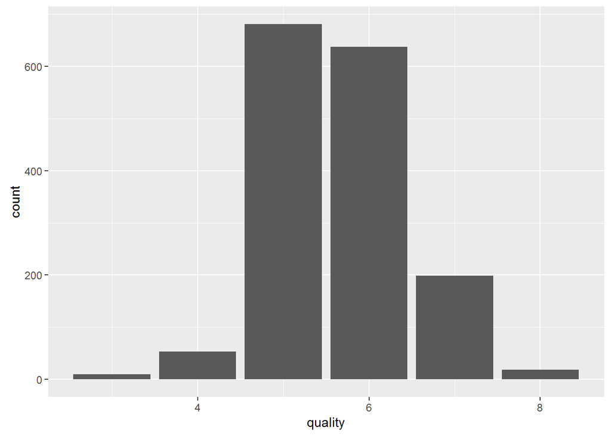

```
##    Min. 1st Qu.  Median    Mean 3rd Qu.    Max.
##   3.000   5.000   6.000   5.636   6.000   8.000
```

```
##
##   3   4   5   6   7   8
##  10  53 681 638 199  18
```

It seems there are just integer values of quality. We might need to transform the variable going forward. Most of the wine samples have a quality of 5,6 or 7.

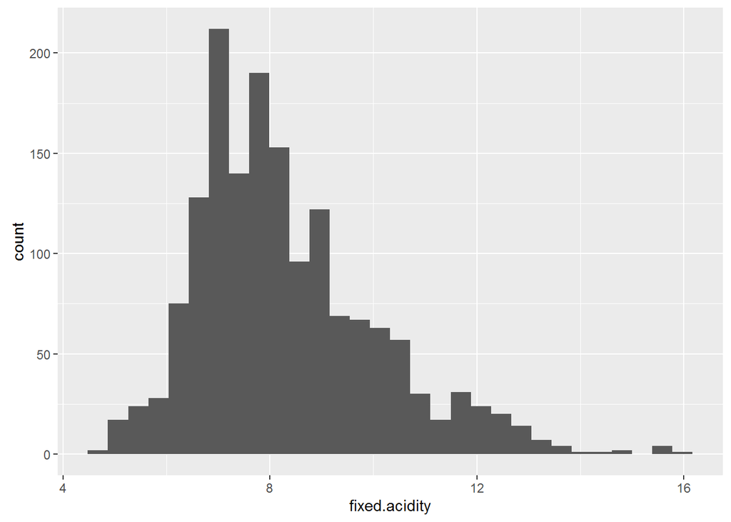

```
##    Min. 1st Qu.  Median    Mean 3rd Qu.    Max.
##    4.60    7.10    7.90    8.32    9.20   15.90
```

Fixed acidity is slightly skewed to the right. Most of the values are between 6 and 10.

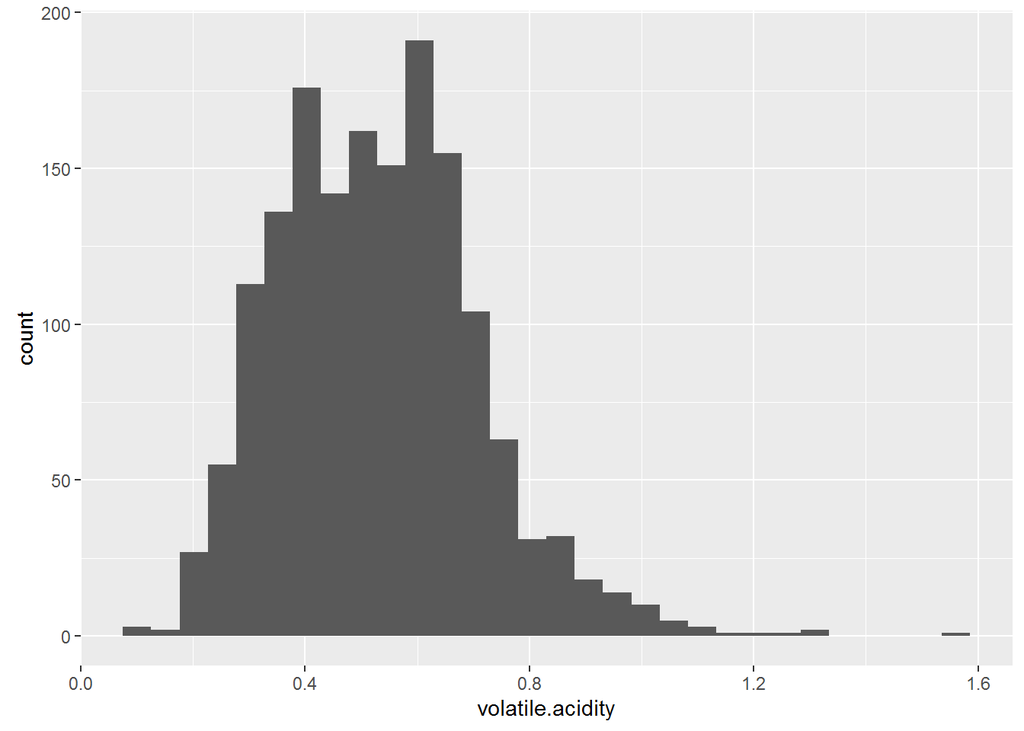

```
##    Min. 1st Qu.  Median    Mean 3rd Qu.    Max.
##  0.1200  0.3900  0.5200  0.5278  0.6400  1.5800
```

Volatile acidity is slightly skewed to the right. There are a few outliers which might be responsible for influencing the quality.

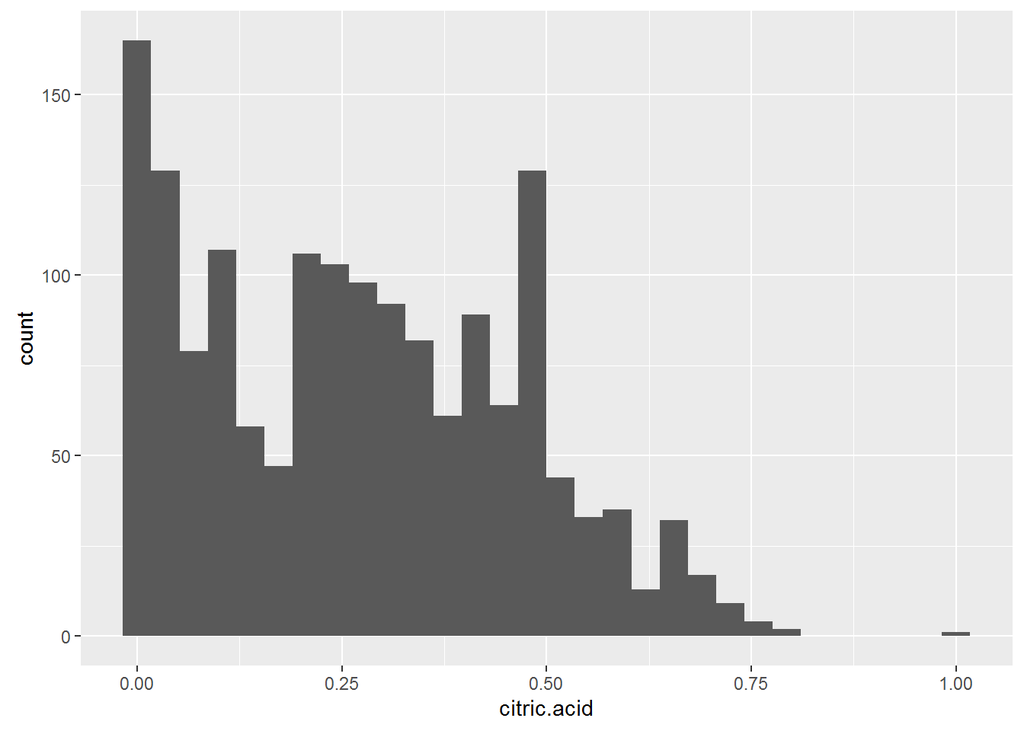

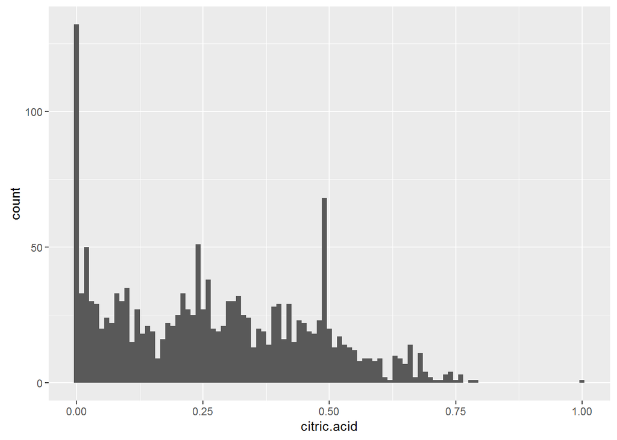

After reducing the binwidth, we see that the citric.acid value increases and decreases a few times with a lot of samples having 0

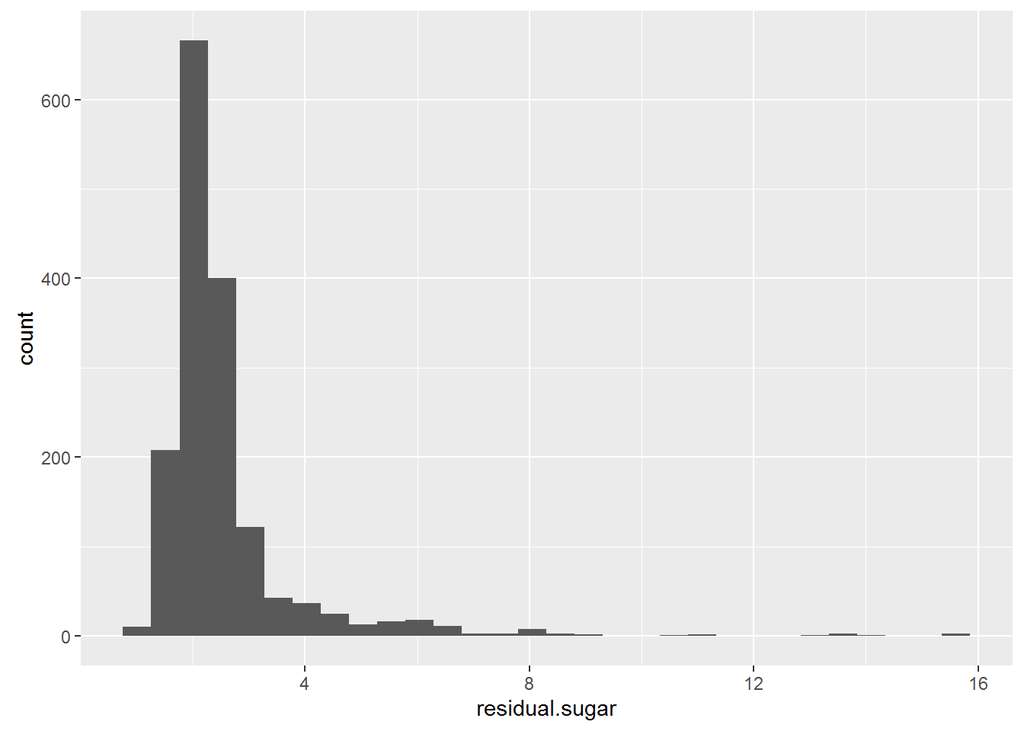

```
##    Min. 1st Qu.  Median    Mean 3rd Qu.    Max.
##   0.900   1.900   2.200   2.539   2.600  15.500
```

Residual.sugar has a positively skewed distribution

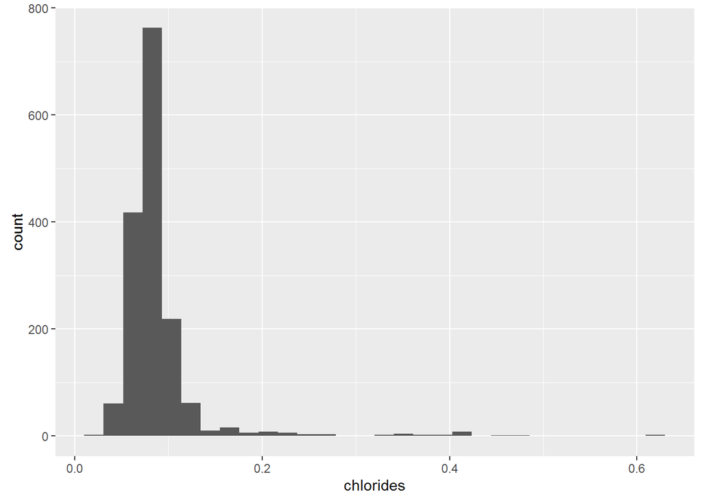

```
##    Min. 1st Qu.  Median    Mean 3rd Qu.    Max.
## 0.01200 0.07000 0.07900 0.08747 0.09000 0.61100
```

Chlorides also has a positively skewed distribution similar to Residual.sugar. We can log transform the data to have a better idea.

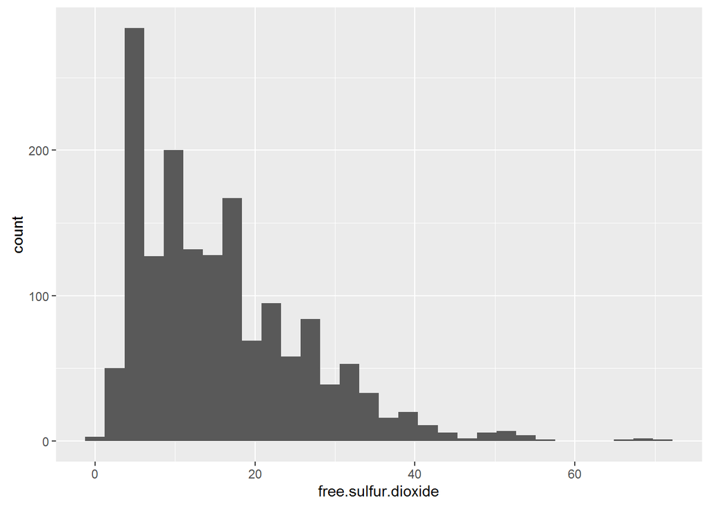

```
##    Min. 1st Qu.  Median    Mean 3rd Qu.    Max.
##    1.00    7.00   14.00   15.87   21.00   72.00
```

free.sulfur.dioxide has a positively skewed distribution with a few outliers.

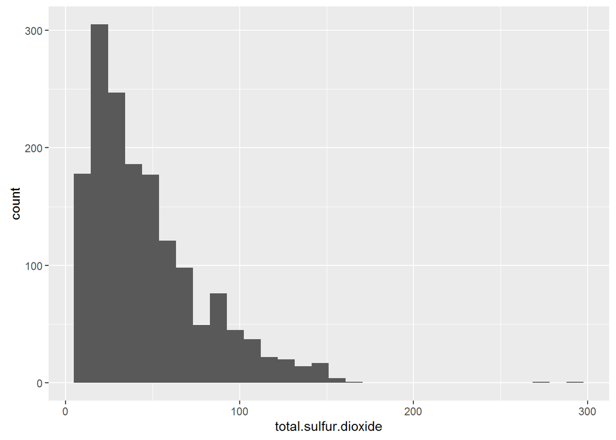

```
##    Min. 1st Qu.  Median    Mean 3rd Qu.    Max.
##    6.00   22.00   38.00   46.47   62.00  289.00
```

```
##
##    6    7    8    9   10   11   12   13   14   15   16   17   18   19   20
##    3    4   14   14   27   26   29   28   33   35   26   27   35   29   33
##   21   22   23   24   25   26   27   28   29   30   31   32   33   34   35
##   25   25   34   36   27   24   30   43   20   14   32   20   17   20   26
##   36   37   38   39   40   41   42   43   44   45   46   47   48   49   50
##   12   26   31   16   17   14   26   18   23   20   17   24   21   21   11
##   51   52   53   54   55   56   57   58   59   60   61   62   63   64   65
##   11   15   14   20   13   10    6   14    9   18    9    9   13   10   17
##   66   67   68   69   70   71   72   73   74   75   76   77 77.5   78   79
##    9   12   10    8    8    7   10    7    8    5    3    8    2    4    5
##   80   81   82   83   84   85   86   87   88   89   90   91   92   93   94
##    4    6    4    2    6    9   10    6   14    9    5    7    8    2    8
##   95   96   98   99  100  101  102  103  104  105  106  108  109  110  111
##    4    5    7    6    3    4    6    2    5    5    6    3    4    6    3
##  112  113  114  115  116  119  120  121  122  124  125  126  127  128  129
##    3    4    2    2    1    7    2    4    3    3    2    1    2    2    3
##  130  131  133  134  135  136  139  140  141  142  143  144  145  147  148
##    1    3    3    2    2    2    1    1    3    1    2    3    3    3    2
##  149  151  152  153  155  160  165  278  289
##    1    2    1    1    1    1    1    1    1
```

Total.sulfur.dioxide has a few outliers at around 289. It seems total.sulfur.dioxide has mostly integer values. It has a positively skewed distribution.

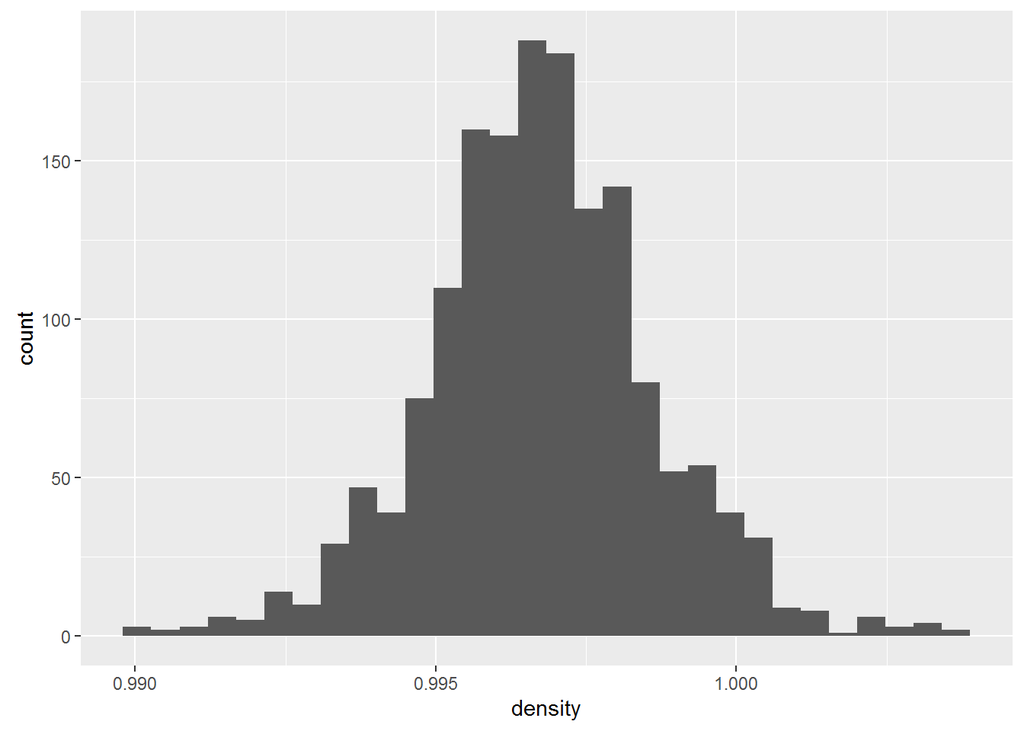

```
##    Min. 1st Qu.  Median    Mean 3rd Qu.    Max.
##  0.9901  0.9956  0.9968  0.9967  0.9978  1.0040
```

Density has normal distribution and it varies across a very small scale.

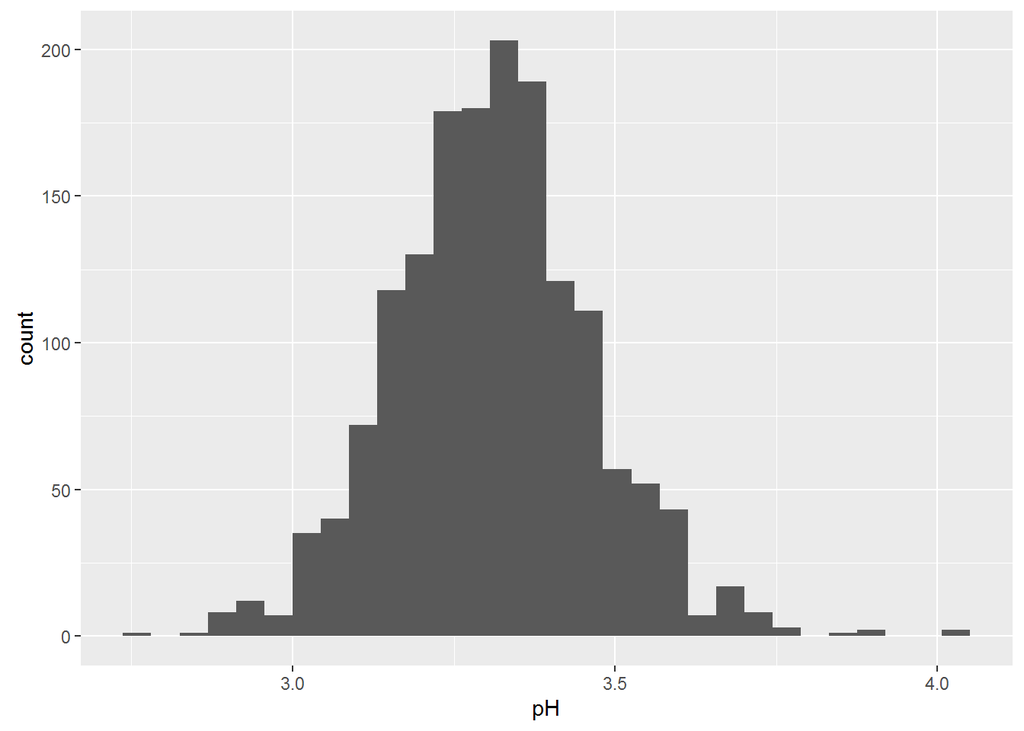

```
##    Min. 1st Qu.  Median    Mean 3rd Qu.    Max.
##   2.740   3.210   3.310   3.311   3.400   4.010
```

pH has a normal distribution. As this is a measure of acidity, this might have correlation with fixed.acidity and volatile.acidity

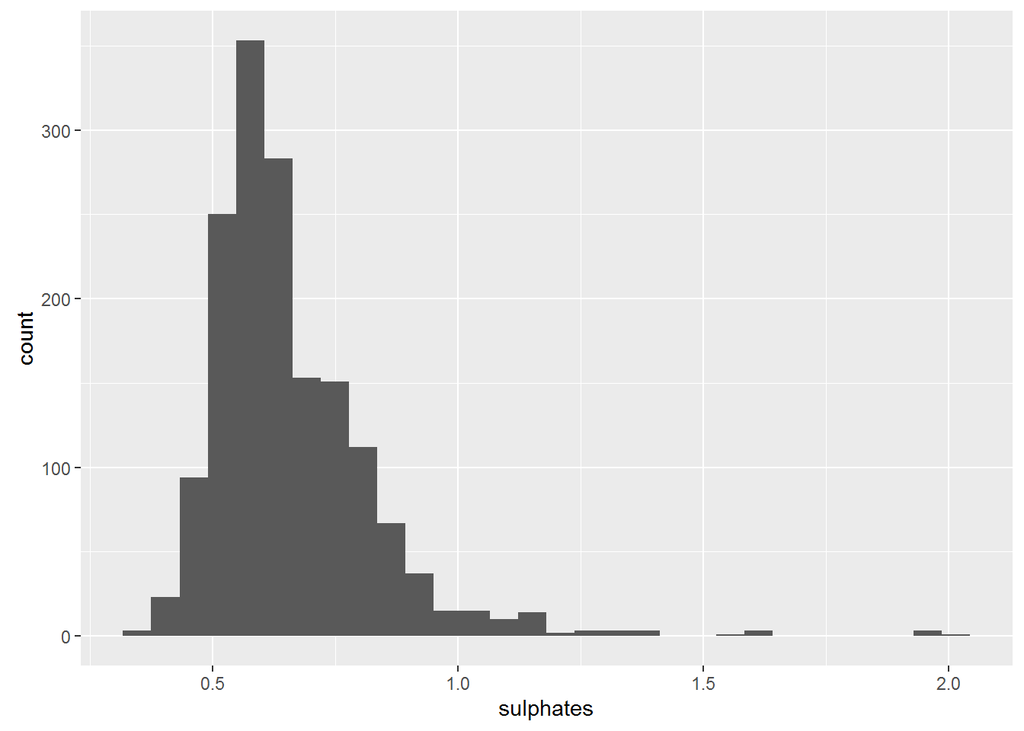

```
##    Min. 1st Qu.  Median    Mean 3rd Qu.    Max.
##  0.3300  0.5500  0.6200  0.6581  0.7300  2.0000
```

Sulphates have a few outliers at the positive end of the scale.

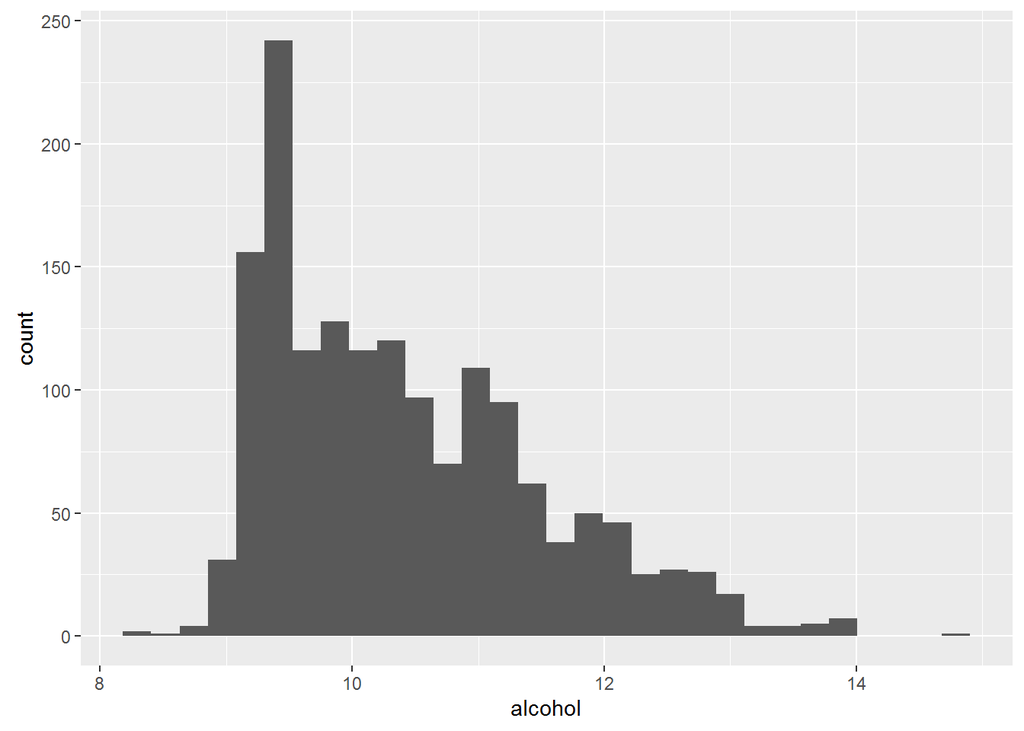

```
##    Min. 1st Qu.  Median    Mean 3rd Qu.    Max.
##    8.40    9.50   10.20   10.42   11.10   14.90
```

Alcohol has a positively skewed distribution. Alcohol seems to be a very important variable and it might have a strong correlation with quality.

# Univariate Analysis

Variables citric.acid,residual.sugar,chlorides,free.sulphur.dioxide,total.sulphur.dioxide and sulphates have a skewed distribution with a long right tail.

For the positively skewed variables, lets transform them using log transofrmations so as to obtain a normal distribution

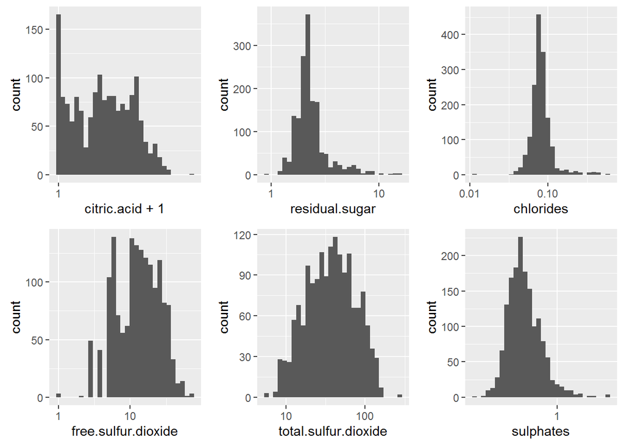

### Main feature of Interest

The main feature of interest in this dataset is the quality of Wine and this investigation will be directed towards finding what factors affect the quality.

### Other features of interest which will help us support our investigation

From first glance, it seems fixed.acidity, volatile.acidity,citric.acid,alcohol will be features that might have an influence on quality.

The univariate analysis does not provide us much insight. We need to look into some of the variables together inorder to figure out which of them might be related.

# Bivariate Analysis

Lets have a look at the correlation between various variables

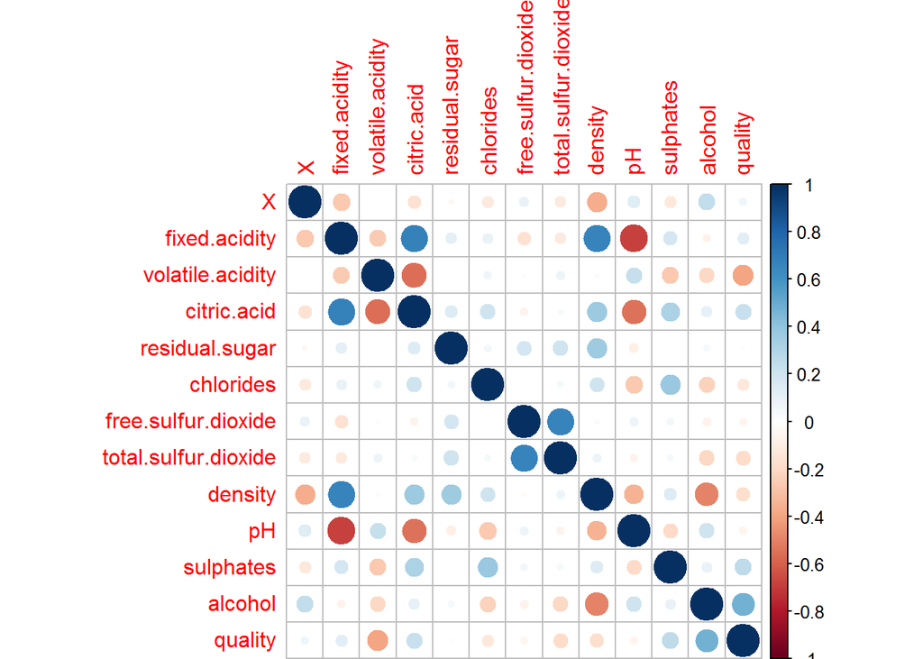

From the plots , it seems that there is strong positive correlation between

1. fixed.acidity and citric.acid
2. fixed.acidity and density
3. free.sulfur.dioxide and total.sulfur.dioxide

Also, there is strong negartive correlation between

1. fixed.acidity and pH
2. volatile.acidity and citric.acid
3. pH and citric.acid

## Negative relationships:

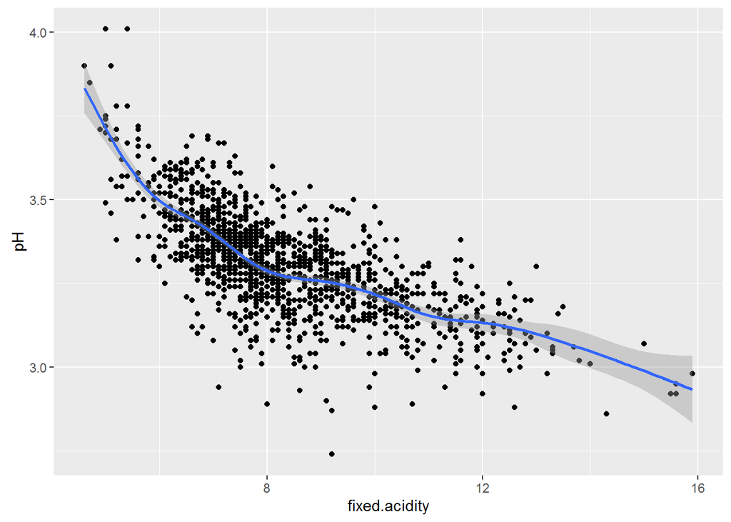

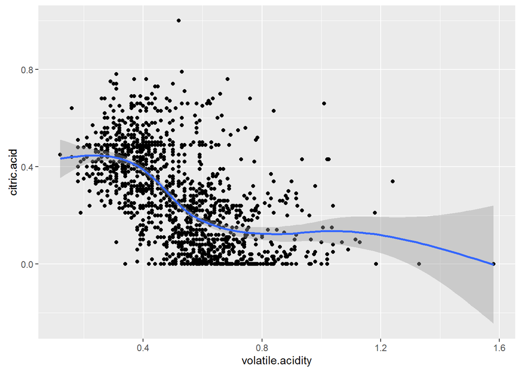

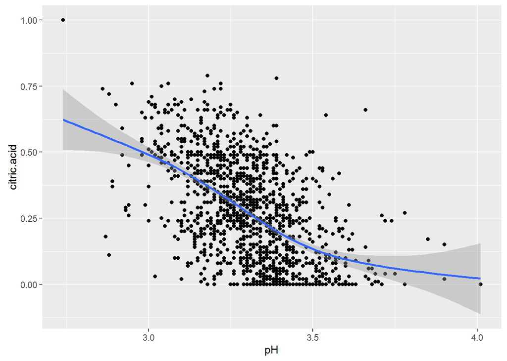

The relationship between pH and fixed.acidity and between pH and citric.acid seems obvious as pH is a measure of acidity.Also, free.sulfur.dioxide being a part of total.sulfur.dioxide explains the relationship between them.

So, going forward, we will narrow down our approach and not look at variables which are dependent on some other variable.

### Creating a new Variable

We need to have a look at the independent variables together with quality. But first, it might be a good idea to create another variable quality.grade which will have 3 grades: bad, average and good.

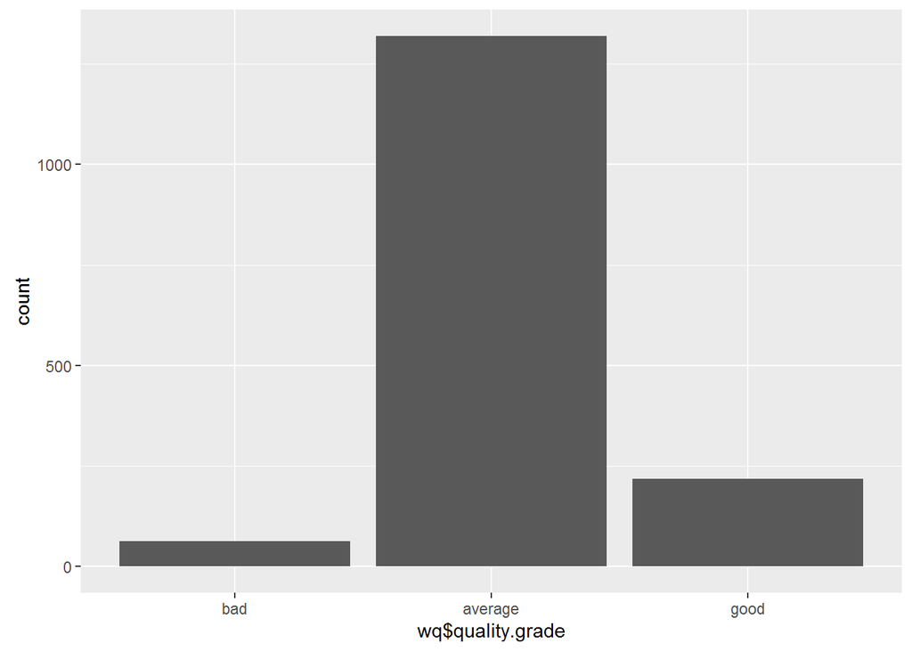

Now,lets have a look at the independent variables and quality

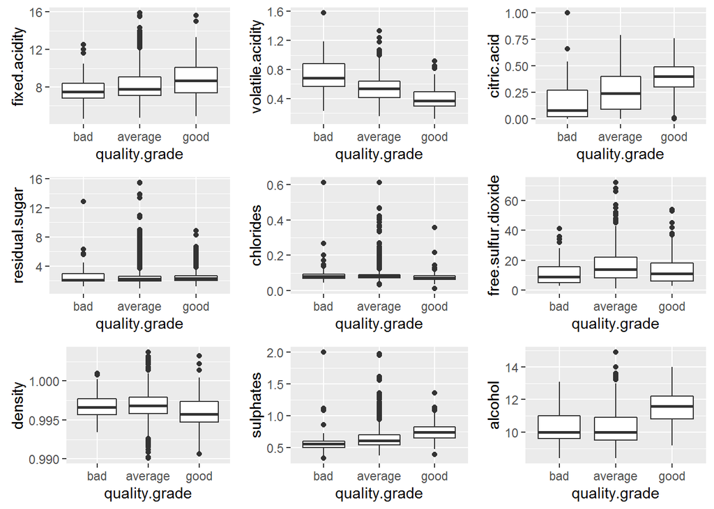

From the above plots,we can conclude that the following variables have a significant correlation with quality:

fixed.acidity:positive

volatile.acidity:negative

citric.acid:positive

sulphates:positive

### Strongest Relatioship

However, one important point to note is that, although there is a linear relationship between some variables such as fixed.acidity and quality, it is obvious that we cannot increase the fixed.acidity infinitely and expect the quality to increase infinitely as well. There must be some upper bound.From common sense, we can say that anything whose quality depends on taste has to have a proper balance of various ingredients or different tastes.Thus, it may be a good idea to find the ratio of various variables and whether they have any relation to quality.This may help us uncover hidden trends.

```
## [1] -0.3905578
```

We want to combine variables which increases the strength of the relationship.After a lot of trial and error, it seems the combination of volatile.acidity,alcohol,density,sulphates have a strong correlation with quality.

```
## [1] -0.4924791
```

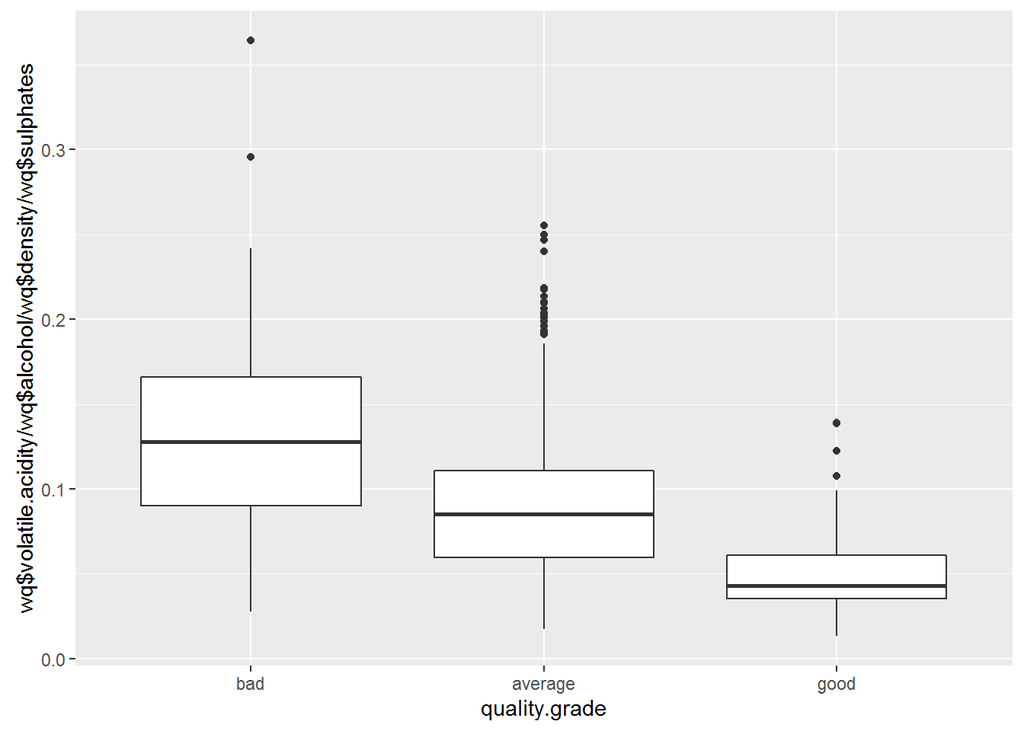

The variance also decreases with increase in quality.

Lets try a combination of variables with positive correlation

```
## [1] 0.1412152
```

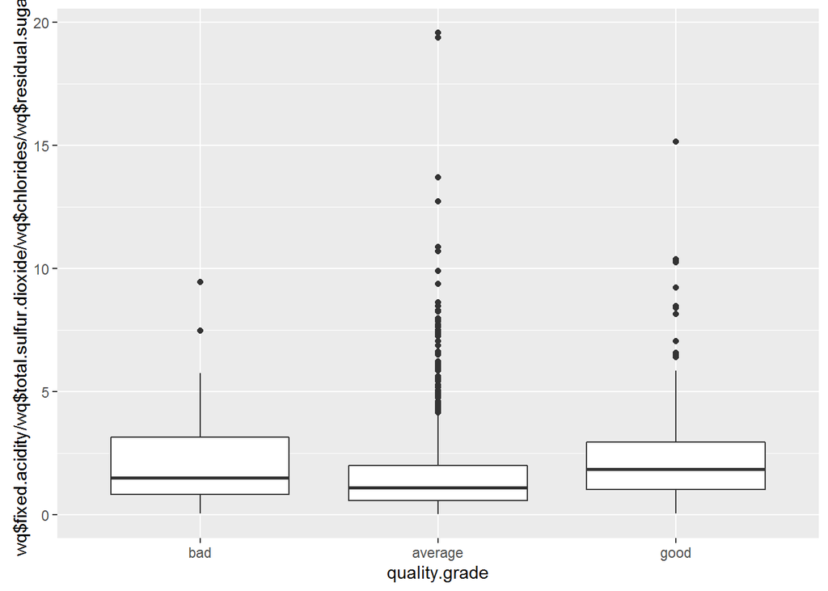

This is not as strong as the negative relationship.Further inclusion of more variables in the equation does not strengthen the relation.

# Multivariate Plots

Let’s try to look at multiple variables at the same time.We are looking at the pairs of independent variables which have a strong correlation with each other and how the quality varies with it.

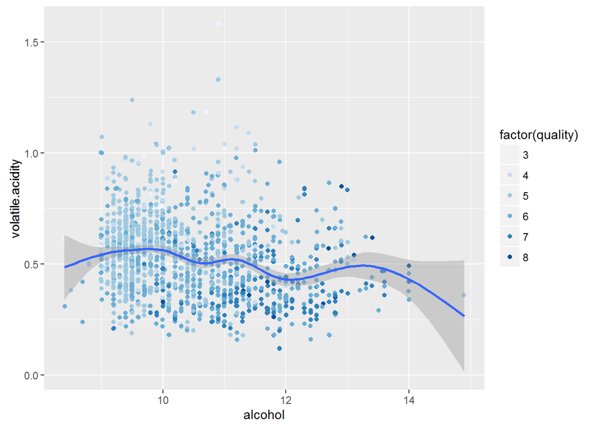

The darker points which represent better quality wine are concentrated to the bottom right corner which is in line with our understanding so far, quality has a negative correlation with volatile.acidity and positively correlated with alcohol.

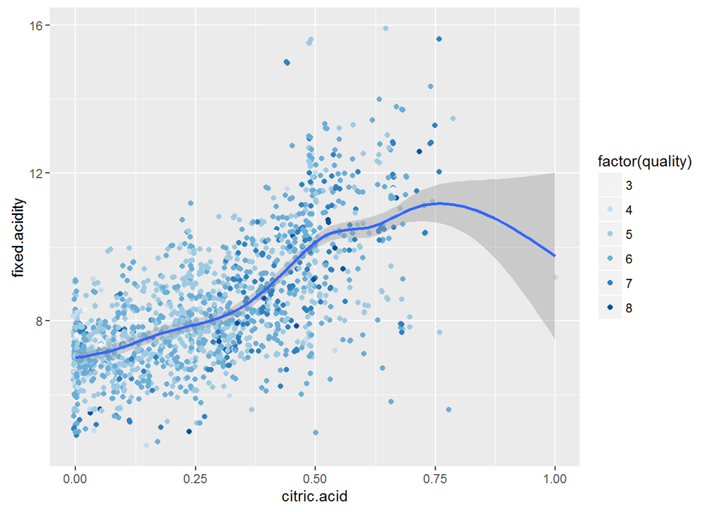

In this case, the pattern is not very clear

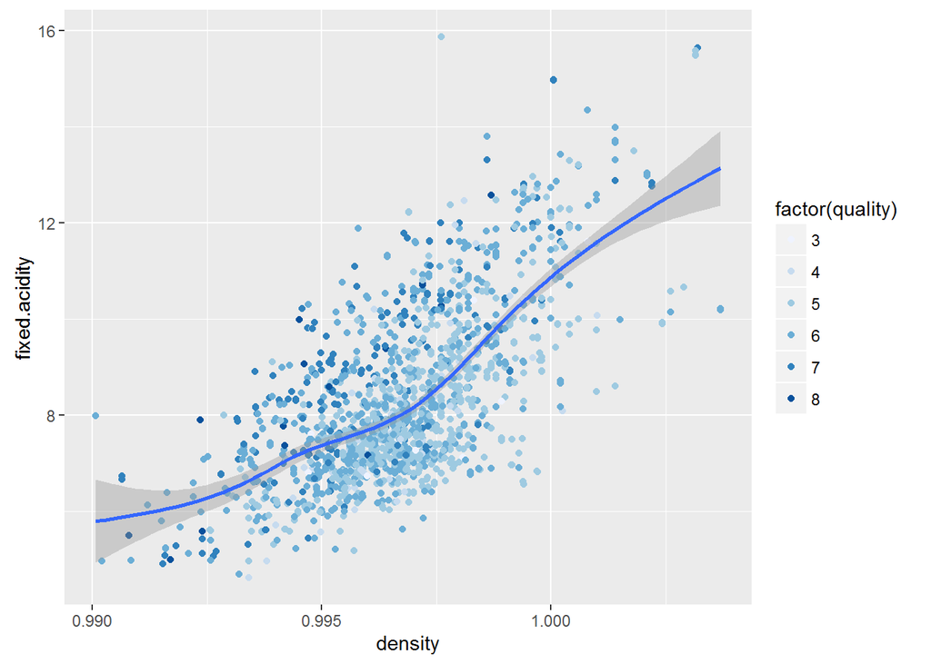

Fixed.acidity has a positive correlation with quality. It is not influenced by density.

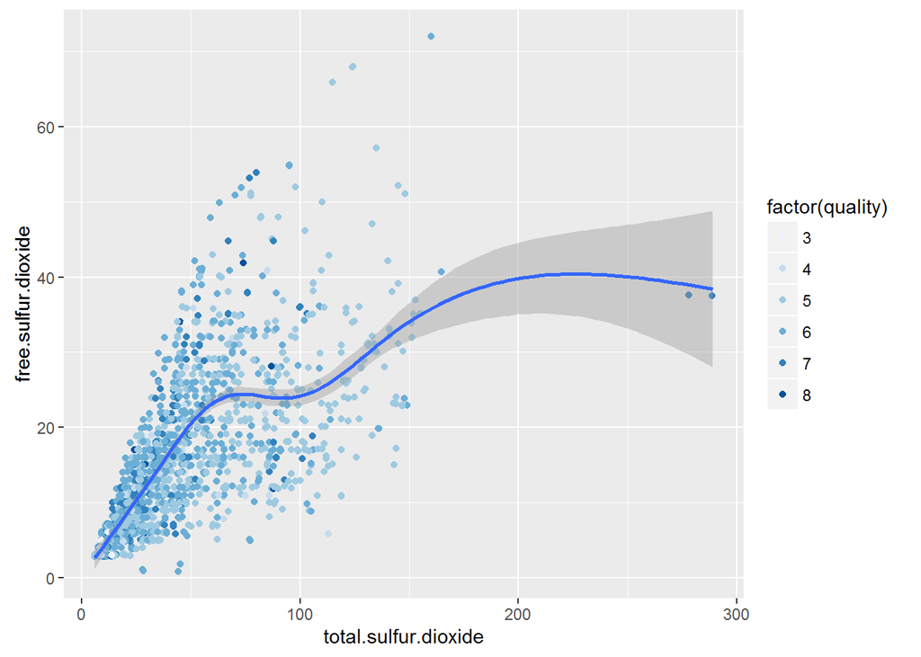

Here again, the pattern is not very clear.

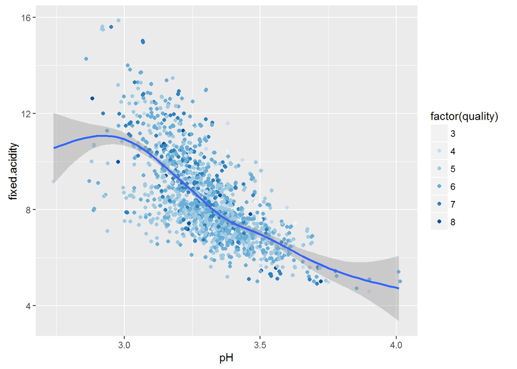

Most of the darker points are concentrated to the left. But the pattern is not very clear.

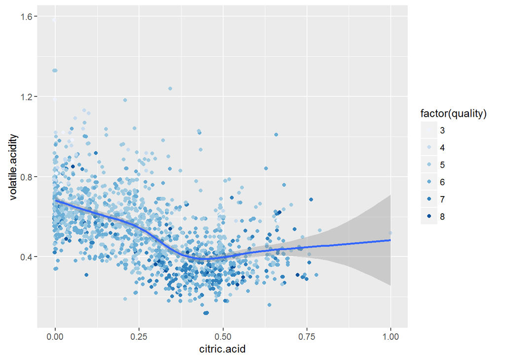

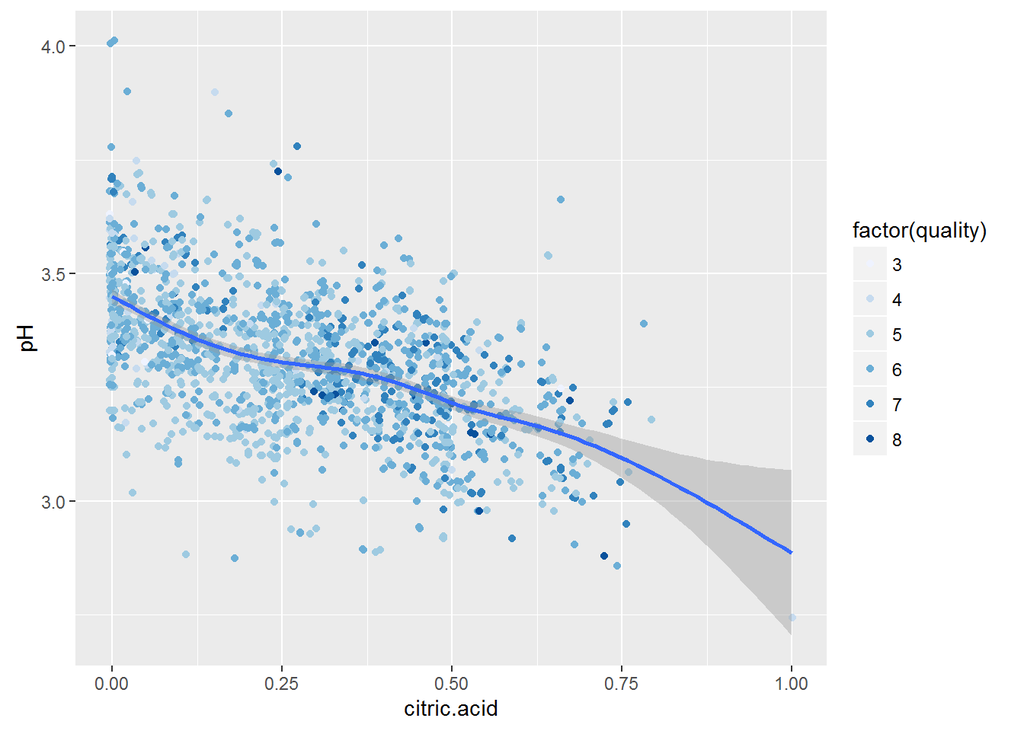

Most of the dark points are concentrated to the bottom right corner which shows the negative correlation between pH and quality and the positive correlation between citric.acid and quality.

All the multivariate plots that we saw above are in line with our understanding so far.

### Predictive model

Since the relation between the ratio of volatile.acidity and alcohol to quality is linear, lets create a predictive model for the same.

```
##
## Call:
## lm(formula = quality ~ (volatile.acidity), data = wq)
##
## Residuals:
##      Min       1Q   Median       3Q      Max
## -2.79071 -0.54411 -0.00687  0.47350  2.93148
##
## Coefficients:
##                  Estimate Std. Error t value Pr(>|t|)
## (Intercept)       6.56575    0.05791  113.39   <2e-16 ***
## volatile.acidity -1.76144    0.10389  -16.95   <2e-16 ***
## ---
## Signif. codes:  0 '***' 0.001 '**' 0.01 '*' 0.05 '.' 0.1 ' ' 1
##
## Residual standard error: 0.7437 on 1597 degrees of freedom
## Multiple R-squared:  0.1525, Adjusted R-squared:  0.152
## F-statistic: 287.4 on 1 and 1597 DF,  p-value: < 2.2e-16
```

```
##
## Call:
## lm(formula = quality ~ volatile.acidity + wq$alcohol, data = wq)
##
## Residuals:
##      Min       1Q   Median       3Q      Max
## -2.59342 -0.40416 -0.07426  0.46539  2.25809
##
## Coefficients:
##                  Estimate Std. Error t value Pr(>|t|)
## (Intercept)       3.09547    0.18450   16.78   <2e-16 ***
## volatile.acidity -1.38364    0.09527  -14.52   <2e-16 ***
## wq$alcohol        0.31381    0.01601   19.60   <2e-16 ***
## ---
## Signif. codes:  0 '***' 0.001 '**' 0.01 '*' 0.05 '.' 0.1 ' ' 1
##
## Residual standard error: 0.6678 on 1596 degrees of freedom
## Multiple R-squared:  0.317,  Adjusted R-squared:  0.3161
## F-statistic: 370.4 on 2 and 1596 DF,  p-value: < 2.2e-16
```

# Final Plots and Summary

### Plot One

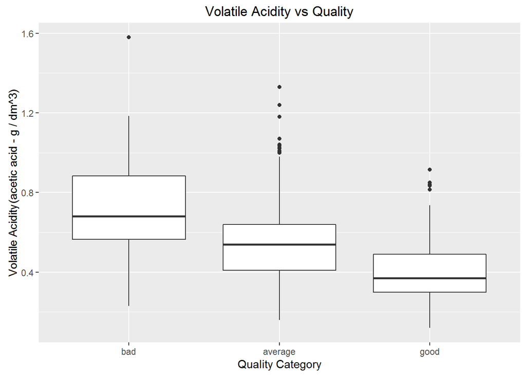

```
## [1] -0.3905578
```

### Plot Two

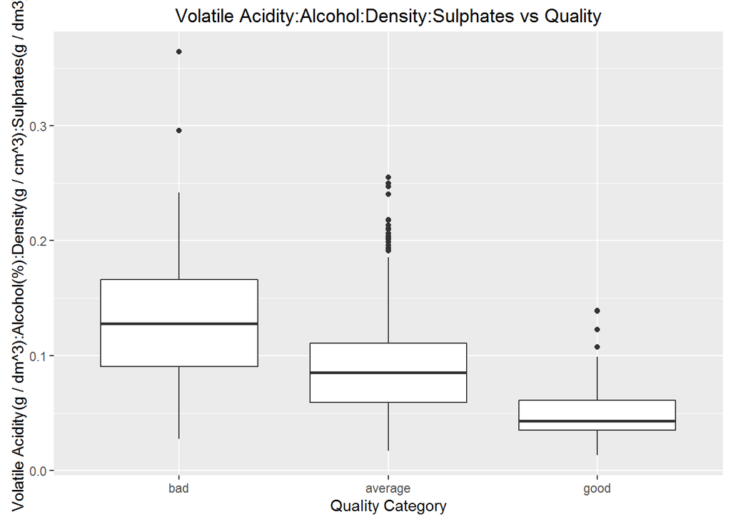

```
## [1] -0.4924791
```

### Plot Three

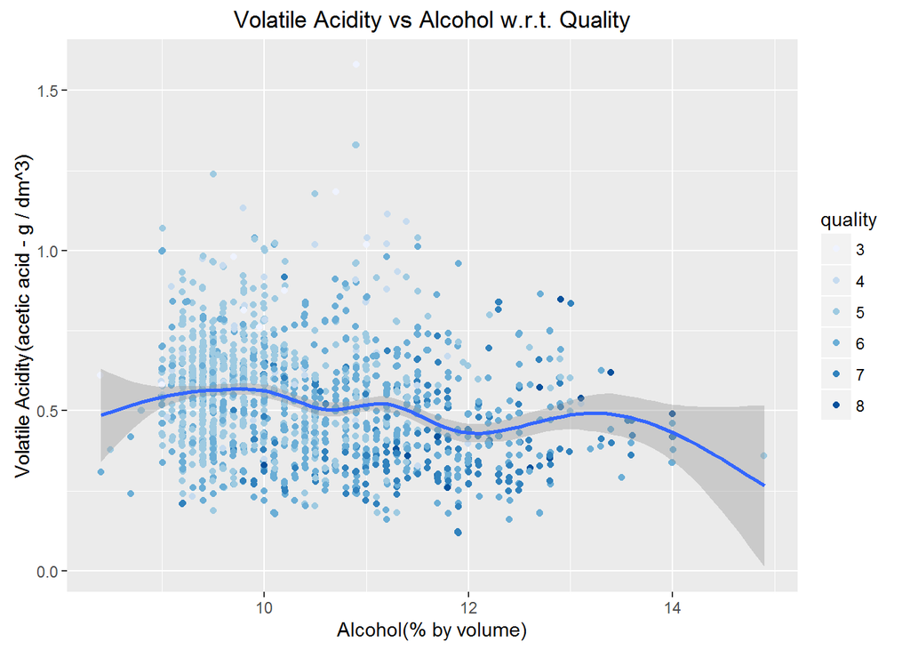

### Description Three

Volatile acidity and alcohol have the strongest influence on quality. On plotting them together, a clear pattern emerges and we can see that most of the darker points ( representing higher quality) are concentrated on the bottom right corner.This reinforces our earlier findings about the correlation between volatile acidity and quality and between alcohol and quality.

# Reflection

First we plotted the indiviadual variables and checked out their distribution.One problem that we faced here was the lack of enough data. There were very few samples for the various wine qualities and most of them were of the average quality.We found the correlation between the various variables and also with respect to quality and then we explored the strongest relationships in detail.This helped us provide a direction to our analysis and distinguish important variables from not so important ones.As is the case with any consumable item, the quality often depends on a combination of ingredients or various tastes rather than individual variables.We were able to achieve a stronger correlation with quality by combining various variables together.The multivariate plots helped enforce our understanding of the relationships so far.Finally, we created a predictive model which is able to account for 31.7 percent of the variance.

One problem that is often faced with such items is that the relationships between the independent variables and the dependent variable does not continue to be in one direction. There is a lower and an upper limit for all the variables. It is more of an optimization problem where we need to find the perfect mix.Furthermore, the quality in this case is determined by individuals and the sense of taste can vary from person to person.Also, some people can be more generous compared to others in their rating. One way to solve this can be to have all the samples tasted by a larger sample of people and then find the average of the rating for each of the samples.